# HW2

## **Data Wrangling**

You will need to download two datasets from https://github.com/USCbiostats/data-science-data. The [individual](https://raw.githubusercontent.com/USCbiostats/data-science-data/master/01_chs/chs_individual.csv) and [regional](https://raw.githubusercontent.com/USCbiostats/data-science-data/master/01_chs/chs_regional.csv) CHS datasets in `01_chs`. The individual data includes personal and health characteristics of children in 12 communities across Southern California. The regional data include air quality measurements at the community level. Once downloaded, you can merge these datasets using the location variable. Once combined, you will need to do the following:

```r
library(data.table)
indiv <- data.table::fread("/Users/vikaskunta/Downloads/chs_individual.csv")
region <- data.table::fread("/Users/vikaskunta/Downloads/chs_regional.csv")
merged <- merge(indiv, region, by="townname", all=FALSE)
```

1. After merging the data, make sure you don't have any duplicates by counting the number of rows. Make sure it matches.

   In the case of missing values, impute data using the average amongst individuals with the same values for the "male" and "hispanic" variables. For categorical variables, take the mode. If you are interested (and feel adventurous) in the theme of Data Imputation, take a look at this paper on "Multiple Imputation" using the Amelia R package [here](https://gking.harvard.edu/files/gking/files/amelia_jss.pdf).

   ```r
   library(dplyr)
   library(dtplyr)
   library(quarto)
   library(knitr)
   library(kableExtra)
   find_mode <- function(x) {
     ux <- unique(x)
     ux[which.max(tabulate(match(x, ux)))]
   }
   cat <- c("asthma", "father_asthma", "mother_asthma", "wheeze", "hayfever", "allergy", "educ_parent", "smoke", "gasstove")
   contin <- c("agepft", "height", "weight", "bmi", "fev", "fvc", "mmef", "pm2_5_fr", "no_24hr")
   imputemerge <- merged %>%
     group_by(male, hispanic) %>%
     mutate(across(all_of(cat),
                   ~ ifelse(is.na(.), as.character(find_mode(as.character(.))), .)),
            across(all_of(contin),
                   ~ ifelse(is.na(.), mean(., na.rm = TRUE), .))) %>%
   ungroup()
   ```

2. Create a new categorical variable named "obesity_level" using the BMI measurement (underweight BMI<14; normal BMI 14-22; overweight BMI 22-24; obese BMI>24). To make sure the variable is rightly coded, create a summary table that contains the minimum BMI, maximum BMI, and the total number of observations per category.

   ```r
   obesity_level <- function(bmi) {
     ifelse(bmi < 14, "Underweight", ifelse(bmi >= 14 & bmi < 22, "Normal", ifelse(bmi >= 22 & bmi < 24, "Overweight", "Obese")))
   }
   imputemerge <- imputemerge %>%
     mutate(obesity_level = obesity_level(bmi))

   BMIsummarytable <- imputemerge %>%
     group_by(obesity_level) %>%
     summarize(
       minimumBMI = min(bmi, na.rm = TRUE),
       maximumBMI = max(bmi, na.rm = TRUE),
       nBMI = n()
     )
   BMIsummarytable
   ```

   ```
   # A tibble: 4 × 4
     obesity_level minimumBMI maximumBMI  nBMI
     <chr>              <dbl>      <dbl> <int>
   1 Normal              14.0       22.0   975
   2 Obese               24.0       41.3   103
   3 Overweight          22.0       24.0    87
   4 Underweight         11.3       14.0    35
   ```

3. Create another categorical variable named "smoke_gas_exposure" that summarizes "Second Hand Smoke" and "Gas Stove." The variable should have four categories in total.

   ```r
   imputemerge <- imputemerge %>%
     mutate(smoke_gas_exposure = case_when(
       smoke == 0 & gasstove == 0 ~ "No Smoke Nor Gas Exposure",
       smoke == 1 & gasstove == 0 ~ "Second-Hand Smoke Exposure",
       smoke == 0 & gasstove == 1 ~ "Gas Stove Exposure",
       smoke == 1 & gasstove == 1 ~ "Both Second-Hand Smoke and Gas Stove Exposure"
     ))
   ```

4. Create four summary tables showing the average (or proportion, if binary) and sd of "Forced expiratory volume in 1 second (ml)" (an asthma indicator) by town, sex, obesity level, and "smoke_gas_exposure."

   ```r
   town_table <- imputemerge %>%
     group_by(townname) %>%
     summarize(
       average_fev = mean(fev, na.rm = TRUE),
       sd_fev = sd(fev, na.rm = TRUE)
     )
   sex_table <- imputemerge %>%
     group_by(male) %>%
     summarize(
       average_fev = mean(fev, na.rm = TRUE),
       sd_fev = sd(fev, na.rm = TRUE)
     )
   obesity_table <- imputemerge %>%
     group_by(obesity_level) %>%
     summarize(
       average_fev = mean(fev, na.rm = TRUE),
       sd_fev = sd(fev, na.rm = TRUE)
     )
   smoke_gas_exposure_table <- imputemerge %>%
     group_by(smoke_gas_exposure) %>%
     summarize(
       average_fev = mean(fev, na.rm = TRUE),
       sd_fev = sd(fev, na.rm = TRUE)
     )
   town_table
   ```

   ```
   # A tibble: 12 × 3
      townname      average_fev sd_fev
      <chr>               <dbl>  <dbl>
    1 Alpine              2087.   291.
    2 Atascadero          2076.   324.
    3 Lake Elsinore       2039.   304.
    4 Lake Gregory        2085.   320.
    5 Lancaster           2003.   317.
    6 Lompoc              2034.   351.
    7 Long Beach          1986.   319.
    8 Mira Loma           1985.   325.
    9 Riverside           1990.   278.
   10 San Dimas           2027.   319.
   11 Santa Maria         2026.   312.
   12 Upland              2024.   343.
   ```

   ```r
   sex_table
   ```

   ```
   # A tibble: 2 × 3
      male average_fev sd_fev
     <int>       <dbl>  <dbl>
   1     0       1959.   312.
   2     1       2104.   308.
   ```

   ```r
   obesity_table
   ```

   ```
   # A tibble: 4 × 3
     obesity_level average_fev sd_fev
     <chr>               <dbl>  <dbl>
   1 Normal              2000.   295.
   2 Obese               2266.   325.
   3 Overweight          2224.   317.
   4 Underweight         1698.   303.
   ```

   ```r
   smoke_gas_exposure_table
   ```

   ```
   # A tibble: 4 × 3
     smoke_gas_exposure                            average_fev sd_fev
     <chr>                                               <dbl>  <dbl>
   1 Both Second-Hand Smoke and Gas Stove Exposure       2025.   301.
   2 Gas Stove Exposure                                  2023.   319.
   3 No Smoke Nor Gas Exposure                           2057.   329.
   4 Second-Hand Smoke Exposure                          2056.   296.
   ```

## **Looking at the Data (EDA)**

The primary questions of interest are:

1. What is the association between BMI and FEV (forced expiratory volume)?

   ```r
   library(ggplot2)
   str(imputemerge$bmi)
   ```

   ```
    num [1:1200] 15.3 15.9 19.4 16.6 15.8 ...
   ```

   ```r
   str(imputemerge$fev)
   ```

   ```
    num [1:1200] 2529 1738 2122 2467 2252 ...
   ```

   ```r
   summary(imputemerge$fev)
   ```

   ```
      Min. 1st Qu.  Median    Mean 3rd Qu.    Max.
     984.8  1827.6  2016.4  2030.1  2223.6  3323.7
   ```

   ```r
   summary(imputemerge$bmi)
   ```

   ```
      Min. 1st Qu.  Median    Mean 3rd Qu.    Max.
     11.30   15.96   17.81   18.50   19.99   41.27
   ```

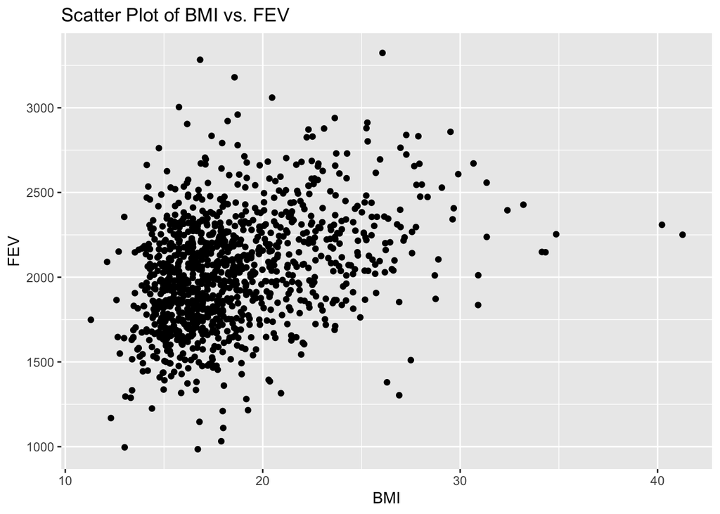

   ```r
   ggplot(imputemerge, aes(x = bmi, y = fev)) +
     geom_point() +
     labs(x = "BMI", y = "FEV", title = "Scatter Plot of BMI vs. FEV")
   ```

   Based off the trend presented in the scatter plot, it appears that a majority of the subjects fall under the below 20 BMI and below 2500 FEV levels. It looks like it could be somewhat linear as BMI increases, FEV seems to as well but the potential outliers to the right of the graph may nullify that.
2. What is the association between smoke and gas exposure and FEV?

   ```r
   str(imputemerge$smoke_gas_exposure)
   ```

   ```
    chr [1:1200] "No Smoke Nor Gas Exposure" "No Smoke Nor Gas Exposure" ...
   ```

   ```r
   str(imputemerge$fev)
   ```

   ```
    num [1:1200] 2529 1738 2122 2467 2252 ...
   ```

   ```r
   summary(imputemerge$smoke_gas_exposure)
   ```

   ```
      Length     Class      Mode
        1200 character character
   ```

   ```r
   summary(imputemerge$fev)
   ```

   ```
      Min. 1st Qu.  Median    Mean 3rd Qu.    Max.
     984.8  1827.6  2016.4  2030.1  2223.6  3323.7
   ```

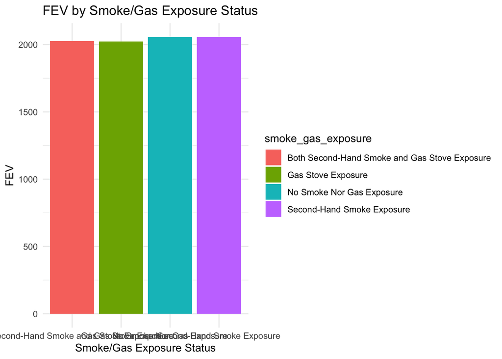

   ```r
   ggplot(imputemerge, aes(x = smoke_gas_exposure, y = fev, fill = smoke_gas_exposure)) +
     geom_bar(stat = "summary", fun = "mean", position = "dodge") +
     labs(x = "Smoke/Gas Exposure Status", y = "FEV", title = "FEV by Smoke/Gas Exposure Status") +
     theme_minimal()
   ```

   It appears that there is no relationship between the two as the FEV levels are basically equivalent to the various forms of smoke/gas exposure analyzed.
3. What is the association between PM2.5 exposure and FEV?

   ```r
   str(imputemerge$pm25_mass)
   ```

   ```
    num [1:1200] 8.74 8.74 8.74 8.74 8.74 8.74 8.74 8.74 8.74 8.74 ...
   ```

   ```r
   str(imputemerge$fev)
   ```

   ```
    num [1:1200] 2529 1738 2122 2467 2252 ...
   ```

   ```r
   summary(imputemerge$pm25_mass)
   ```

   ```
      Min. 1st Qu.  Median    Mean 3rd Qu.    Max.
     5.960   7.615  10.545  14.362  20.988  29.970
   ```

   ```r
   summary(imputemerge$fev)
   ```

   ```
      Min. 1st Qu.  Median    Mean 3rd Qu.    Max.
     984.8  1827.6  2016.4  2030.1  2223.6  3323.7
   ```

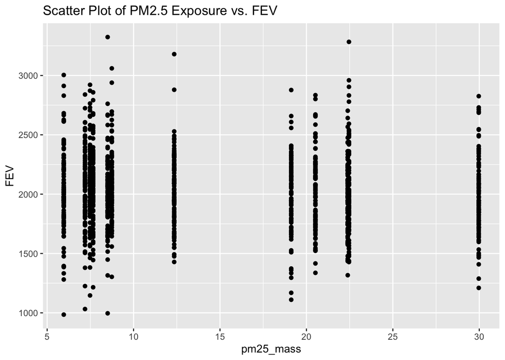

   ```r
   ggplot(imputemerge, aes(x = pm25_mass, y = fev)) +
     geom_point() +
     labs(x = "pm25_mass", y = "FEV", title = "Scatter Plot of PM2.5 Exposure vs. FEV")
   ```

The graph shows uniformity as the levels seem relatively equal to one another suggesting that there is not linear relationship between PM2.5 exposure and FEV.

Follow the EDA checklist from week 3 and the previous assignment. Be sure to focus on the key variables.

## **Visualization**

Create the following figures and interpret them. Be sure to include easily understandable axes, titles, and legends.

1. Facet plot showing scatterplots with regression lines of BMI vs FEV by "townname".

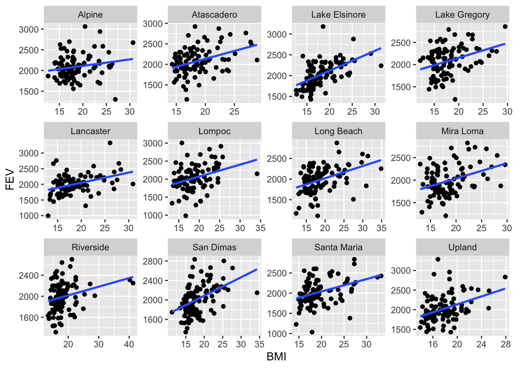

   ```r
   library(ggplot2)
   ggplot(imputemerge, aes(x = bmi, y = fev)) +
     geom_point() +
     geom_smooth(method = "lm", se = FALSE) +
     facet_wrap(~ townname, scales = "free") +
     labs(x = "BMI", y = "FEV")
   ```

   ```r
     ggtitle("Facet Plot of BMI vs FEV by Townname")
   ```

   ```
   $title
   [1] "Facet Plot of BMI vs FEV by Townname"

   attr(,"class")
   [1] "labels"
   ```

   Each town has a positive regression trend in similar direction and shapes but some towns such as Mira Loma and Lake Gregory and Atascadero are a lot more scattered than the others while a town like Riverside a vast majority of results are in the lower BMI portion of the x asis. There seems to be a couple of extreme BMI values in each one but almost all the graphs show a over 90% of subjects below the 25 BMI mark.
2. Stacked histograms of FEV by BMI category and FEV by smoke/gas exposure. Use different color schemes than the ggplot default.

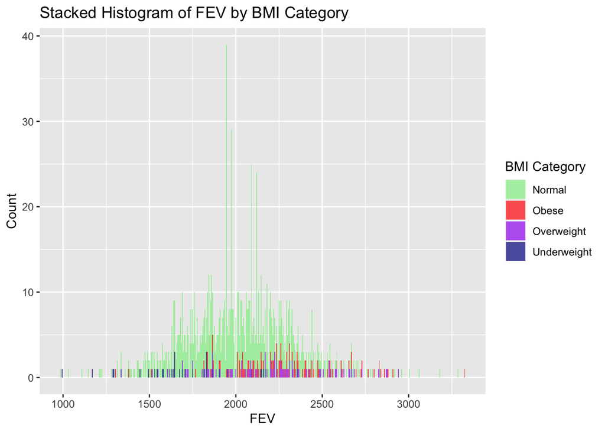

   ```r
   color_bmi <- c("lightgreen", "red", "purple", "darkblue")
   color_smokegas <- c("maroon", "skyblue", "orange", "darkgreen")

   ggplot(imputemerge, aes(x = fev, fill = factor(obesity_level))) +
     geom_histogram(binwidth = 5, position = "stack", alpha = 0.7) +
     scale_fill_manual(values = color_bmi) +
     labs(x = "FEV", y = "Count", fill = "BMI Category") +
     ggtitle("Stacked Histogram of FEV by BMI Category")
   ```

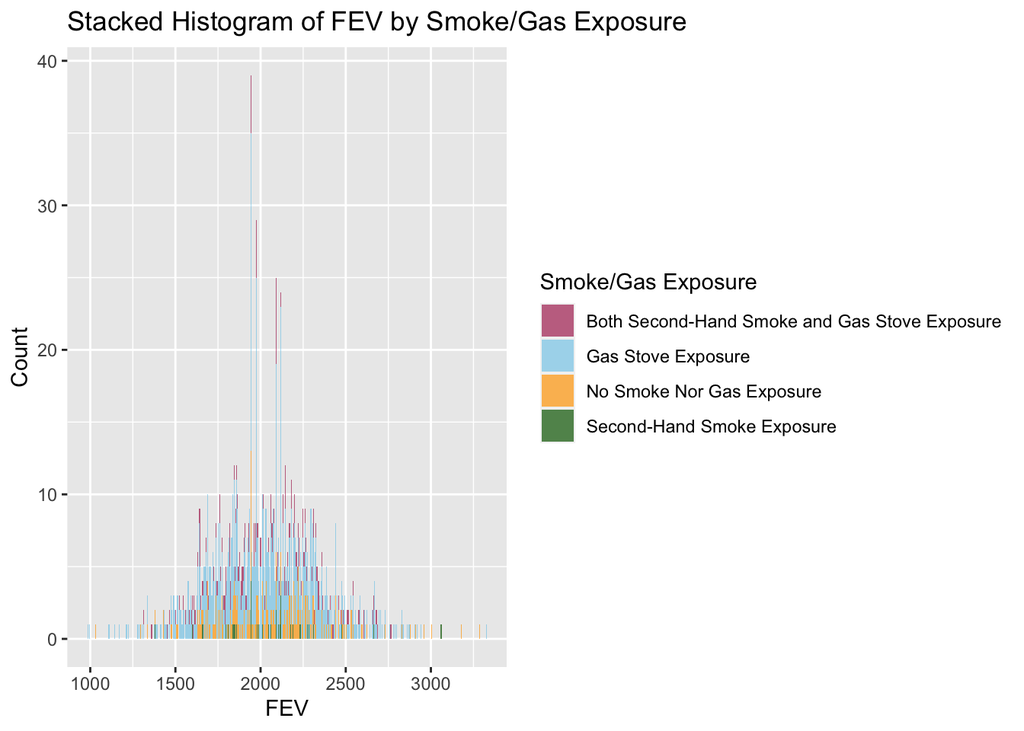

   ```r
   ggplot(imputemerge, aes(x = fev, fill = factor(smoke_gas_exposure))) +
     geom_histogram(binwidth = 5, position = "stack", alpha = 0.7) +
     scale_fill_manual(values = color_smokegas) +
     labs(x = "FEV", y = "Count", fill = "Smoke/Gas Exposure") +
     ggtitle("Stacked Histogram of FEV by Smoke/Gas Exposure")
   ```

   The BMI stacked histogram is showing a majority of the results in the normal category of BMI showing the highest frequencies. The smoke/gas exposure stacked histogram is showing a majority of the results in the gas stove exposure and both second hand smoke and gas stove exposure categories are showing the highest frequencies.
3. Barchart of BMI by smoke/gas exposure.

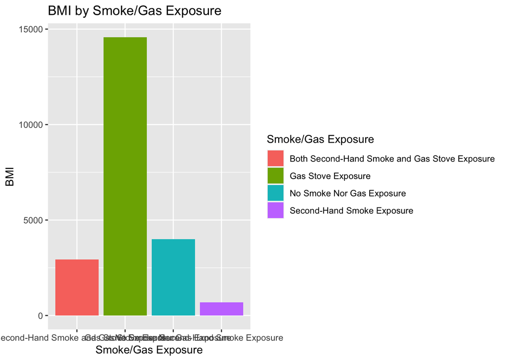

   ```r
   ggplot(imputemerge, aes(x = factor(smoke_gas_exposure), y = bmi, fill = factor(smoke_gas_exposure))) +
     geom_bar(stat = "identity") +
     labs(x = "Smoke/Gas Exposure", y = "BMI", fill = "Smoke/Gas Exposure") +
     ggtitle("BMI by Smoke/Gas Exposure")
   ```

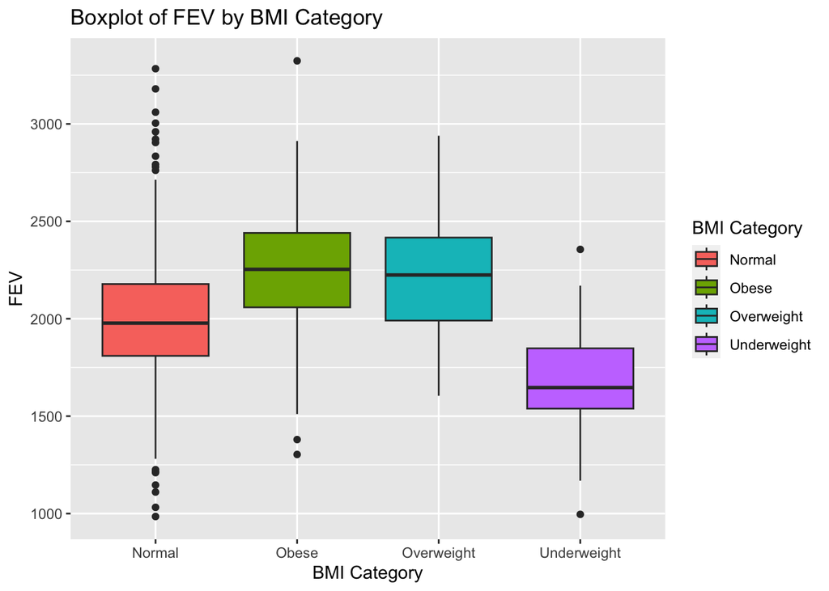

   ```r
   ggplot(imputemerge, aes(x = factor(obesity_level), y = fev, fill = factor(obesity_level))) +
     geom_boxplot() +
     labs(x = "BMI Category", y = "FEV", fill = "BMI Category") +
     ggtitle("Boxplot of FEV by BMI Category")
   ```

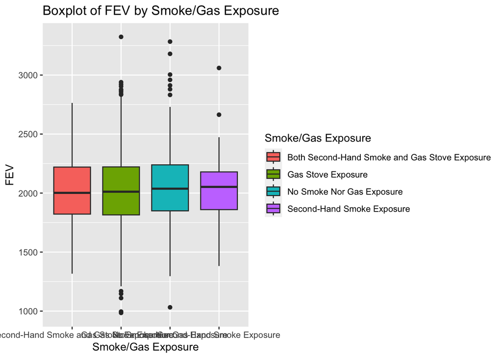

   ```r
   ggplot(imputemerge, aes(x = factor(smoke_gas_exposure), y = fev, fill = factor(smoke_gas_exposure))) +
     geom_boxplot() +
     labs(x = "Smoke/Gas Exposure", y = "FEV", fill = "Smoke/Gas Exposure") +
     ggtitle("Boxplot of FEV by Smoke/Gas Exposure")
   ```

   The bar graph for BMI is showing that obese and overweight folks in this study have higher FEV than the normal and underweight people but the normal people had more outliers than the other groups in both high and low extremes which is interesting. In the smoke/gas exposure one, all 4 of the boxes are very similar in terms of the median but slightly fluctuate in the max and min columns.
5. A leaflet map showing the concentrations of PM2.5 mass in each of the CHS communities.

   ```r
   library(leaflet)
   leaflet() %>%
     addTiles() %>%
     addCircles(
       data = imputemerge,
       lat = ~lat, lng = ~lon,
       opacity = 1, fillOpacity = 0.5, radius = 400,
       color = "blue",
       popup = ~paste("Town Name: ", townname, "<br>PM2.5 Concentration: ", pm25_mass)
     )
   ```

[interactive chart not shown]

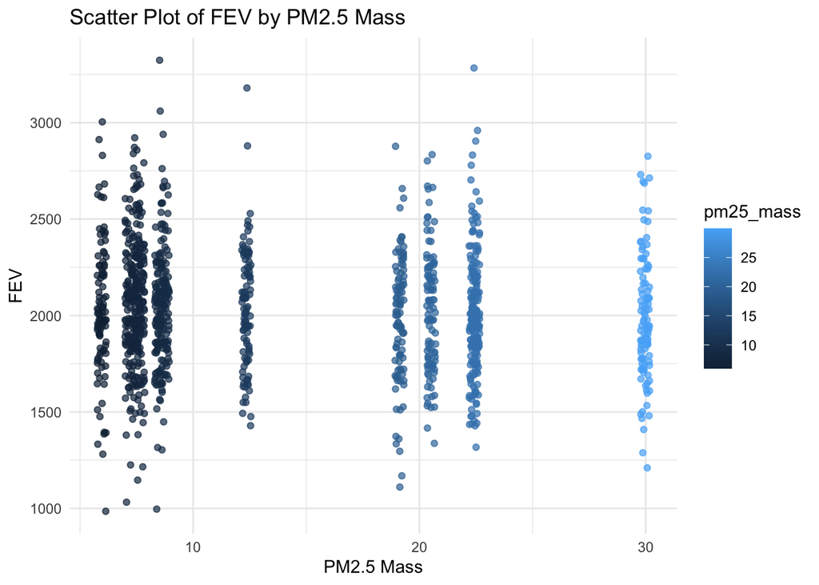

   ```r
   ggplot(imputemerge, aes(x = pm25_mass, y = fev, color = pm25_mass)) +
     geom_jitter(width = 0.2, alpha = 0.7) +
     labs(x = "PM2.5 Mass", y = "FEV", title = "Scatter Plot of FEV by PM2.5 Mass") +
     theme_minimal()
   ```

The lower pm2.5 mass proportion of this study appear to have the highest sample size and the highest and lowest values. The third quadrant we see also has a lot of samples and like all 4 of the main scatters presented, majority of the FEV results fall in the 1500-2500 fev range.